# Ejercicio: Series temporales en GRASS GIS

Autor/a

Verónica Andreo

Fecha de publicación

14 de septiembre de 2023

En esta notebook vamos a recorrer algunas de las funcionalidades de TGRASS que ya vimos y otras nuevas, pero ahora con una serie de datos de NDVI.

Antes de empezar y para ganar tiempo, conectamos nuestro drive e instalamos GRASS en Google Colab.

```python
# import drive from google colab
from google.colab import drive
# mount drive
drive.mount("/content/drive")
```

```python
%%bash
DEBIAN_FRONTEND=noninteractive
sudo add-apt-repository ppa:ubuntugis/ubuntugis-unstable
apt update
apt install grass subversion grass-dev
apt remove libproj22
```

```python
!grass --config path
```

## Datos para el ejercicio

- Producto MODIS: [MOD13C2 Collection 6](https://lpdaac.usgs.gov/products/mod13c2v006/)
- Composiciones globales mensuales
- Período: Enero 2015 - Diciembre 2019
- Resolución espacial: 5600 m
- Mapset `modis_ndvi`

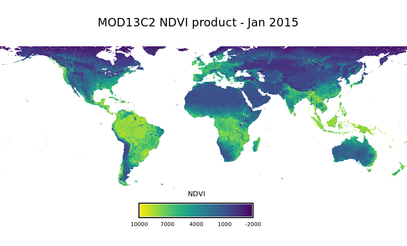

## Iniciamos GRASS

Definimos las rutas y el mapset *`modis_ndvi`* donde vamos a trabajar.

```python
import os

# data directory
homedir = "/content/drive/MyDrive/curso_grass_2023"

# change to homedir so output files will be saved there
os.chdir(homedir)

# GRASS GIS database variables
grassdata = os.path.join(homedir, "grassdata")
project = "posgar2007_4_cba"
mapset = "modis_ndvi"
```

```python
# import standard Python packages we need
import sys
import subprocess

# ask GRASS GIS where its Python packages are to be able to run it from the notebook
sys.path.append(
    subprocess.check_output(["grass", "--config", "python_path"], text=True).strip()
)
```

Importamos los paquetes de GRASS e iniciamos una sesión.

```python
# import the GRASS GIS packages we need
import grass.script as gs
import grass.jupyter as gj

# Start the GRASS GIS Session
session = gj.init(grassdata, project, mapset)
```

```python
# show current GRASS GIS settings, this also checks if the session works
gs.gisenv()
```

## Exploramos los datos de NDVI

Listar los mapas y obtener información de alguno de ellos

```python
# list raster files
lista_mapas = gs.list_grouped(type="raster")["modis_ndvi"]
lista_mapas[:10]
```

```python
#  get info and stats
gs.raster_info(map="MOD13C2.A2015001.006.single_Monthly_NDVI")
```

```python
print(gs.read_command("r.univar",
                      map="MOD13C2.A2015001.006.single_Monthly_NDVI"))
```

**Tarea**

- Mostrar los mapas de NDVI, NIR y pixel reliability.
- Obtener información sobre los valores mínimos y máximos.
- ¿Qué se puede decir sobre los valores de cada banda?
- ¿Hay valores nulos?

## Uso de la banda de confiabilidad

Definir la región computacional

```python
# set computational region
print(gs.read_command("g.region",
                      vector="provincia_cba",
                      align="MOD13C2.A2015001.006.single_Monthly_NDVI",
                      flags="p"))
```

Establecer los límites provinciales como máscara

```python
# set a MASK to Cba boundary
gs.run_command("r.mask",
               vector="provincia_cba")
```

**Tarea**

- Leer acerca de la banda de confiabilidad en la [Guía de usuario](https://lpdaac.usgs.gov/documents/103/MOD13_User_Guide_V6.pdf) de MOD13 (pag 27).
- Para una misma fecha mapear la banda de confiabilidad y el NDVI.
- Seleccionar sólo los pixeles con valor 0 (Buena calidad) en la banda de confiabilidad. ¿Qué se observa?

Vamos a mantener sólo los pixeles de la mejor calidad para un mapa.

```python
# keep only NDVI most reliable pixels (one map)
PR="MOD13C2.A2015274.006.single_Monthly_pixel_reliability"
NDVI="MOD13C2.A2015274.006.single_Monthly_NDVI"

gs.mapcalc(exp=f"{NDVI}_filt = if({PR} != 0, null(), {NDVI})")
```

```python
# plot result
ndvi_filt = gj.InteractiveMap(width = 500, tiles="OpenStreetMap")
ndvi_filt.add_raster("MOD13C2.A2015274.006.single_Monthly_NDVI_filt")
ndvi_filt.show()
```

Ahora hacemos lo mismo para todos los mapas de NDVI.

```python
# list of maps
PR = gs.list_grouped(type="raster",
                     pattern="*_pixel_reliability")["modis_ndvi"]
NDVI = gs.list_grouped(type="raster",
                       pattern="*_Monthly_NDVI")["modis_ndvi"]

# iterate over the 2 arrays
for i,j in zip(PR,NDVI):
    print(i, j)
    gs.mapcalc(exp=f"{j}_filt = if({i} != 0, null(), {j})")
```

**Nota**

Cómo podrían hacer lo mismo pero usando módulos temporales? Qué les parece [t.rast.algebra](https://grass.osgeo.org/grass-stable/manuals/t.rast.algebra.html)? OJO! Esto requiere primero crear las series de tiempo y registrar los mapas para que funcione!

```python
# apply pixel reliability band with t.rast.algebra
expression="NDVI_monthly_filt = if(pixel_rel_monthly != 0, null(), ndvi_monthly)"

gs.run_command("t.rast.algebra",
               expression=expression,
               basename="ndvi_monthly",
               suffix="gran",
               nproc=4)
```

**Tarea**

Comparar las estadísticas entre los mapas de NDVI originales y filtrados para la misma fecha

## Creación de la serie de tiempo

Crear STRDS de NDVI

```python
# create STRDS
gs.run_command("t.create",
               type="strds",
               temporaltype="absolute",
               output="ndvi_monthly",
               title="Filtered monthly NDVI",
               description="Filtered monthly NDVI - MOD13C2 - Cordoba, 2015-2019")
```

Corroborar que la STRDS fue creada

```python
# check if it was created
gs.read_command("t.list",
                type="strds")
```

Creamos la lista de mapas

```python
# list NDVI filtered files
NDVI_filt = gs.list_grouped(type="raster",
                            pattern="*_filt")["modis_ndvi"]
NDVI_filt[:10]
```

Asignar fecha a los mapas, i.e., registrar

```python
# register maps
gs.run_command("t.register",
               input="ndvi_monthly",
               maps=NDVI_filt,
               start="2015-01-01",
               increment="1 months",
               flags="i")
```

Imprimir info básica de la STRDS

```python
# print time series info
print(gs.read_command("t.info",
                      input="ndvi_monthly"))
```

Imprimir la lista de mapas en la STRDS

```python
# print list of maps in time series
print(gs.read_command("t.rast.list",
                      input="ndvi_monthly"))
```

También podemos obtener los valores para un único pixel o para un vector de puntos. Para eso usamos [t.rast.what](https://grass.osgeo.org/grass-stable/manuals/t.rast.what.html).

```python
# Get region center coordinates for query
gs.region(complete=True)
```

```python
# Query map at center coordinates
gs.read_command("t.rast.what",
                strds="ndvi_monthly",
                coordinates="4426800,6428800",
                layout="col",
                flags="n",
                output="ts.csv",
                separator="comma",
                null_value=" ")
```

**Tarea**

Explorar visualmente los valores de las series temporales en diferentes puntos. Usar [g.gui.tplot](https://grass.osgeo.org/grass-stable/manuals/g.gui.tplot.html) y seleccionar diferentes puntos interactivamente.

```python
import pandas as pd

# abrir archivo ts.csv como DataFrame
df = pd.read_csv('ts.csv')

# crear columna data y llenarla con el anio y mes de la columna start
df['date'] = df['start'].str.extract('(^[0-9]*-[0-9]*)')

# eliminar Nan
df = df.dropna()

# cambiar nombre de la columna
df.rename(columns = {'4426800.0000000000;6428800.0000000000':'NDVI'}, inplace = True)
```

```python
# crear gráfico
import matplotlib.pyplot as plt
plt.figure(figsize=(15, 7))
plt.plot(df['date'],df['NDVI'])
plt.xticks(rotation = 90)
plt.show();
```

## Datos faltantes

Obtener las estadísticas de la serie de tiempo

```python
# How much missing data we have after filtering for pixel reliability?
print(gs.read_command("t.rast.univar",
                      input="ndvi_monthly"))
```

Contar los datos válidos

```python
# count valid data
gs.run_command("t.rast.series",
               input="ndvi_monthly",
               method="count",
               output="ndvi_count_valid")
```

Estimar el porcentaje de datos faltantes

```python
# estimate percentage of missing data
gs.mapcalc(exp="ndvi_missing = ((60 - ndvi_count_valid) * 100.0)/60")
```

Cómo guardar en una variable el numero de mapas de una serie de tiempo?

```python
n = gs.parse_command("t.info",
                     input="ndvi_monthly",
                     flags="g")["number_of_maps"]
n
```

```python
gs.mapcalc(exp=f"ndvi_missing = (({n} - ndvi_count_valid) * 100.0)/{n}")
```

**Tarea**

- Mostrar el mapa que representa el porcentaje de datos faltantes.
- Obtener estadísticas univariadas de este mapa.
- Dónde estan los mayores porcentajes de datos faltantes? Por qué creen que puede ser?

## Reconstrucción temporal: HANTS

- Harmonic Analysis of Time Series (HANTS)
- Implementado en la extensión [r.hants](https://grass.osgeo.org/grass-stable/manuals/addons/r.hants.html)

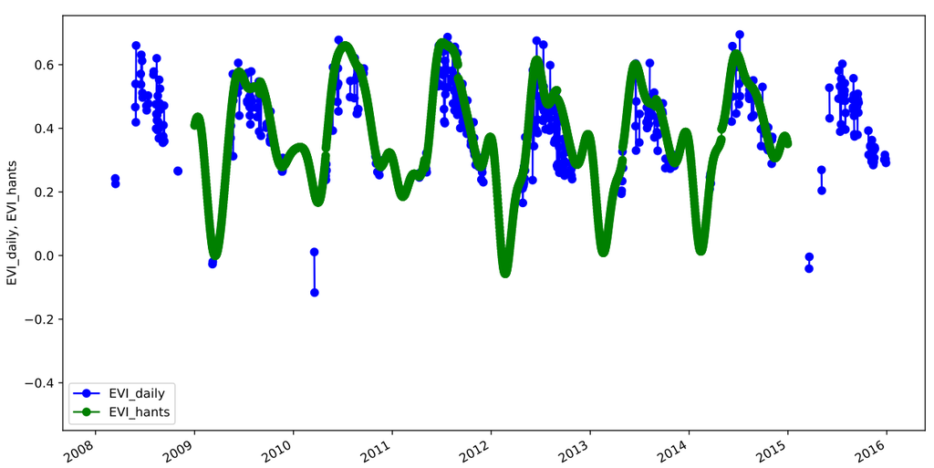

Instalar la extensión *r.hants*

```python
# install extension
gs.run_command("g.extension",
               extension="r.hants")
```

Listar los mapas y aplicar r.hants

```python
# list maps
maplist = gs.parse_command("t.rast.list",
                          input="ndvi_monthly",
                          columns="name",
                          method="comma",
                          flags="u")
maplist = list(maplist.keys())
```

```python
# gapfill: r.hants
gs.run_command("r.hants",
               input=maplist,
               range=[-2000,10000],
               nf=5,
               fet=500,
               base_period=12)
```

```python
# list filled maps
gs.list_grouped(type="raster",
                pattern="*hants")["modis_ndvi"]
```

**Tarea**

Probar diferentes ajustes de parámetros en [r.hants](https://grass.osgeo.org/grass-stable/manuals/addons/r.hants.html) y comparar los resultados

Parcheamos un mapa de la serie original y con el reconstruido

```python
# patch original with filled (one map)
NDVI_ORIG = "MOD13C2.A2015001.006.single_Monthly_NDVI_filt"
NDVI_HANTS = "MOD13C2.A2015001.006.single_Monthly_NDVI_filt_hants"

gs.run_command("r.patch",
               input=[NDVI_ORIG, NDVI_HANTS],
               output=f"{NDVI_HANTS}_patch")
```

Ahora parcheamos todos los mapas de la serie original y reconstruida

```python
# list of maps
ORIG = gs.list_grouped(type="raster",
                     pattern="*_filt")["modis_ndvi"]
FILL = gs.list_grouped(type="raster",
                       pattern="*_hants")["modis_ndvi"]
```

```python
# patching
for i,j in zip(ORIG,FILL):
    print(i, j)
    out=f"{j}_patch"
    gs.run_command("r.patch",
                   input=[i, j],
                   output=out)
```

Creamos la serie de tiempo con los datos parcheados y registramos los mapas.

```python
# create new time series
gs.run_command("t.create",
               output="ndvi_monthly_patch",
               type="strds",
               temporaltype="absolute",
               title="Patched monthly NDVI",
               description="Filtered, gap-filled and patched monthly NDVI - MOD13C2 - Cordoba, 2015-2019")
```

```python
# list NDVI patched files
patched_maps = gs.list_grouped(type="raster",
                               pattern="*patch")["modis_ndvi"]
patched_maps[:5]
```

```python
# register maps
gs.run_command("t.register",
               flags="i",
               input="ndvi_monthly_patch",
               type="raster",
               maps=patched_maps,
               start="2015-01-01",
               increment="1 months")
```

Imprimir información de la serie de tiempo

```python
# print time series info
print(gs.read_command("t.info",
                      input="ndvi_monthly_patch"))
```

**Tarea**

- Evaluar gráficamente los resultados de la reconstrucción de HANTS en pixeles con mayor porcentaje de datos faltantes
- Obtener estadísticas univariadas para las nuevas series temporales

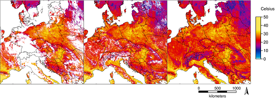

**Tarea**

- Ver la sección de métodos en Metz et al. (2017)
- Qué otros algoritmos existen o qué otra aproximación podría seguirse?

## Agregación con granularidad

**Tarea**

- Obtener el promedio de NDVI cada dos meses
- Visualizar la serie de tiempo resultante con `TimeSeriesMap`

## Indicadores de fenología

### Fecha de ocurrencia de máximos y mínimos

Identificamos primero los máximos y mínimos de la serie, luego reemplazamos con `start_month()` los valores en la STRDS si coinciden con el mínimo o máximo global y finalmente obtenemos el primer mes en el que aparecieron el máximo y el mínimo.

```python
methods = ["maximum","minimum"]

for me in methods:
    # get maximum and minimum
    gs.run_command("t.rast.series",
                   input="ndvi_monthly_patch",
                   method=me,
                   output=f"ndvi_{me}")
    # get month of maximum and minimum
    gs.run_command("t.rast.mapcalc",
                   inputs="ndvi_monthly_patch",
                   output=f"month_{me}_ndvi",
                   expression=f"if(ndvi_monthly_patch == ndvi_{me}, start_month(), null())",
                   basename=f"month_{me}_ndvi")
    # get the earliest month in which the maximum and minimum appeared
    gs.run_command("t.rast.series",
                   input=f"month_{me}_ndvi",
                   method="minimum",
                   output=f"earliest_month_{me}_ndvi")
    # remove intermediate strds
    gs.run_command("t.remove",
                   flags="rfd",
                   inputs=f"month_{me}_ndvi")
```

**Tarea**

- Mostrar los mapas resultantes con `InteractiveMap`
- Cuándo se observan los mínimos y máximos? Hay algun patrón? A qué se podría deber?

**Tarea**

- Asociar el máximo de LST con el máximo de NDVI y, la fecha de la máxima LST con la fecha del máximo NDVI
- Agregar el mapset `modis_lst` a los mapsets accesibles.
- Ver el módulo [r.covar](https://grass.osgeo.org/grass-stable/manuals/r.covar.html).

### Tasa de crecimiento

Obtener series temporales de pendientes entre mapas consecutivos

```python
# time series of slopes
expression = "slope_ndvi = (ndvi_monthly_patch[1] - ndvi_monthly_patch[0]) / td(ndvi_monthly_patch)"

gs.run_command("t.rast.algebra",
               expression=expression,
               basename="slope_ndvi",
               suffix="gran")
```

Obtener la máxima pendiente por año

```python
# get max slope per year
gs.run_command("t.rast.aggregate",
               input="slope_ndvi",
               output="ndvi_slope_yearly",
               basename="NDVI_max_slope_year",
               suffix="gran",
               method="maximum",
               granularity="1 years")
```

**Tarea**

- Obtener un mapa con la mayor tasa de crecimiento por píxel en el período 2015-2019
- Qué modulo usarían?

### Período de crecimiento

Instalar la extensión *r.seasons*

```python
# install extension
gs.run_command("g.extension",
               extension="r.seasons")
```

Determinar el comienzo, el final y la duración del período de crecimiento

```python
# start, end and length of growing season
gs.run_command("r.seasons",
               input=patched_maps,
               prefix="ndvi_season",
               n=3,
               nout="ndvi_season",
               threshold_value=3000,
               min_length=5)
```

**Tarea**

- Qué nos dice cada mapa? Dónde es más larga la estación de crecimiento?
- Exportar los mapas resultantes como .png

Crear un mapa de umbrales para usar en *r.seasons*

```python
# create a threshold map: min ndvi + 0.1*ndvi
gs.mapcalc(exp="threshold_ndvi = ndvi_minimum * 1.1")
```

**Tarea**

Utilizar el mapa de umbrales en [r.seasons](https://grass.osgeo.org/grass-stable/manuals/addons/r.seasons.html) y comparar los mapas de salida con los resultados de utilizar sólo un valor de umbral.

## Serie de tiempo de NDWI

Listas de mapas de reflectancia

```python
list_nir = gs.list_grouped(type="raster",
                           pattern="*NIR*")["modis_ndvi"]
list_mir = gs.list_grouped(type="raster",
                           pattern="*MIR*")["modis_ndvi"]

len(list_nir,list_mir)
```

Asignamos *semantic labels* correspondientes a las bandas

```python
# asign semantic labels to NIR and MIR maps
for i in list_nir:
    gs.run_command("r.support",
                   map=i,
                   semantic_label="nir")

for i in list_mir:
    gs.run_command("r.support",
                   map=i,
                   semantic_label="mir")
```

```python
# check
gs.raster_info("MOD13C2.A2015001.006.single_Monthly_MIR_reflectance")["semantic_label"]
```

Crear series temporales de NIR y MIR

```python
# create time series of NIR and MIR altogether
gs.run_command("t.create",
               output="modis_surf",
               type="strds",
               temporaltype="absolute",
               title="Monthly surface reflectance, NIR and MIR",
               description="NIR and MIR monthly - MOD13C2 - 2015-2019")
```

Registrar mapas

```python
# register maps
gs.run_command("t.register",
               input="modis_surf",
               maps=list_nir,
               start="2015-01-01",
               increment="1 months",
               flags="i")

gs.run_command("t.register",
               input="modis_surf",
               maps=list_mir,
               start="2015-01-01",
               increment="1 months",
               flags="i")
```

Imprimir información de la serie de tiempo

```python
# print time series info
print(gs.read_command("t.info",
                      input="modis_surf"))
```

```python
# List only NIR maps
print(gs.read_command("t.rast.list",
                      input="modis_surf.nir",
                      columns="name,semantic_label"))
```

Estimación de la serie temporal de NDWI

```python
# extract nir and mir strds
sls = ["nir", "mir"]

for sl in sls:
    gs.run_command("t.rast.extract",
                   input="modis_surf",
                   where=f"semantic_label == '{sl}'",
                   output=sl)
```

```python
# estimate NDWI time series
expression="ndwi_monthly = if(nir > 0 && mir > 0, (float(nir - mir) / float(nir + mir)), null())"

gs.run_command("t.rast.algebra",
               basename="ndwi_monthly",
               expression=expression,
               suffix="gran",
               flags="n")
```

```python
# estimate NDWI time series
#gs.run_command("t.rast.mapcalc",
#               inputs="modis_surf.mir,modis_surf.nir",
#               output="ndwi_monthly",
#               basename="ndwi",
#               expression="float(modis_surf.nir - modis_surf.mir) / (modis_surf.nir + modis_surf.mir)")
```

```python
gs.run_command("t.rast.colors",
               input="ndwi_monthly",
               color="ndwi")
```

```python
print(gs.read_command("t.info",
                      input="ndwi_monthly"))
```

**Tarea**

Obtener valores máximos y mínimos para cada mapa de NDWI y explorar el trazado de la serie de tiempo en diferentes puntos de forma interactiva

Ver el manual de [t.rast.univar](https://grass.osgeo.org/grass-stable/manuals/t.rast.univar.html)

### Frecuencia de inundación

Reclasificar los mapas según un umbral

```python
# reclassify
gs.run_command("t.rast.mapcalc",
               input="ndwi_monthly",
               output="flood",
               basename="flood",
               expression="if(ndwi_monthly > 0.8, 1, null())",
               flags="n")
```

Obtener frecuencia de inundación

```python
# flooding frequency
gs.run_command("t.rast.series",
               input="flood",
               output="flood_freq",
               method="sum")
```

**Tarea**

Cuáles son las áreas que se han inundado con más frecuencia?

## Regresión NDVI-NDWI

Instalar la extensión *r.regression.series*

```python
# install extension
gs.run_command("g.extension",
               extension="r.regression.series")
```

Realizar una regresión entre las series temporales de NDVI y NDWI

```python
xseries = patched_maps
yseries = gs.list_grouped(type="raster",
                          pattern="ndwi_monthly*")["modis_ndvi"]

gs.run_command("r.regression.series",
               xseries=xseries,
               yseries=yseries,
               output="ndvi_ndwi_rsq",
               method="rsq")
```

```python
rsq = gj.InteractiveMap(width = 400, use_region=True)
rsq.add_raster("ndvi_ndwi_rsq", opacity=0.8)
rsq.add_layer_control(position = "bottomright")
rsq.show()
```

**Tarea**

Determinar dónde está la mayor correlación entre NDVI y NDWI

## Recursos (muy) útiles

- [Temporal data processing wiki](https://grasswiki.osgeo.org/wiki/Temporal_data_processing)
- [GRASS GIS and R for time series processing wiki](https://grasswiki.osgeo.org/wiki/Temporal_data_processing/GRASS_R_raster_time_series_processing)
- [GRASS GIS temporal workshop at NCSU](http://ncsu-geoforall-lab.github.io/grass-temporal-workshop/)
- [GRASS GIS course IRSAE 2018](http://training.gismentors.eu/grass-gis-irsae-winter-course-2018/index.html)
- [GRASS GIS workshop held in Jena 2023](https://training.gismentors.eu/grass-gis-workshop-jena/)
- [Using Satellite Data for Species Distribution Modeling with GRASS GIS and R](https://veroandreo.github.io/grass_ncsu_2023/studio_index.html). Workshop en NCSU. Abril, 2023.

## Referencias

Metz, M., Andreo, V., y Neteler, M. (2017), «A New Fully Gap-Free Time Series of Land Surface Temperature from MODIS LST Data», *Remote Sensing*, 9, 1333. https://doi.org/10.3390/rs9121333.